# dplyr

Ron Richardson

September 08, 2017

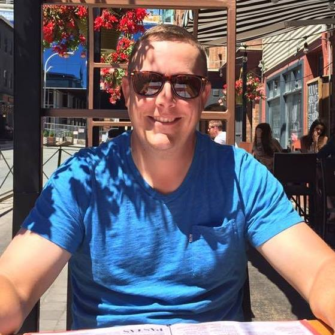

*Ron Richardson is currently is a Data Science student at Mercyhurst University.*

## Filtering Columns and Rows

When using dplyr, you can filter columns and rows by using select and filter. Below is an example using the Lahman baseball database. We first need to load the Lahman and dplyr packages.

```r
library(Lahman)
library(dplyr)
```

Now to find any New York Yankee with over 50 home runs from any year, run the following:

```r
Batting %>%
  select(playerID, yearID, teamID, HR) %>%
  filter(teamID == 'NYA' & HR > 50) %>%
  arrange(desc(HR))
```

```
##    playerID yearID teamID HR
## 1 marisro01   1961    NYA 61
## 2  ruthba01   1927    NYA 60
## 3  ruthba01   1921    NYA 59
## 4  ruthba01   1920    NYA 54
## 5  ruthba01   1928    NYA 54
## 6 mantlmi01   1961    NYA 54
## 7 rodrial01   2007    NYA 54
## 8 mantlmi01   1956    NYA 52
```

## Examples from 09/06/2017 Class

The first example asks for only players of the New York Yankees that have hit 40 HR or more. I’ve added code to order the results from most HR to lowest to get a quick view of the biggest HR hitters.

```r
Batting %>%
  select(yearID, teamID, playerID, HR) %>%
  filter(teamID == 'NYA' & HR >= 40) %>%
  arrange(desc(HR))
```

```
##    yearID teamID  playerID HR
## 1    1961    NYA marisro01 61
## 2    1927    NYA  ruthba01 60
## 3    1921    NYA  ruthba01 59
## 4    1920    NYA  ruthba01 54
## 5    1928    NYA  ruthba01 54
## 6    1961    NYA mantlmi01 54
## 7    2007    NYA rodrial01 54
## 8    1956    NYA mantlmi01 52
## 9    1930    NYA  ruthba01 49
## 10   1934    NYA gehrilo01 49
## 11   1936    NYA gehrilo01 49
## 12   2005    NYA rodrial01 48
## 13   1926    NYA  ruthba01 47
## 14   1927    NYA gehrilo01 47
```

[output cut: 16 more lines]

Next up, we want to see if these big HR hitters can do so without striking out so much. Ordering by the lest amount of strikouts to most helps us figure out the best HR to SO ratio.

```r
Batting %>%
  select(yearID, teamID, playerID, HR, SO) %>%
  filter(HR > 40 & SO < 60) %>%
  arrange(SO)
```

```
##    yearID teamID  playerID HR SO
## 1    1934    NYA gehrilo01 49 31
## 2    1954    CIN kluszte01 49 35
## 3    1937    NYA dimagjo01 46 37
## 4    1929    NY1   ottme01 42 38
## 5    1955    CIN kluszte01 47 40
## 6    2004    SFN bondsba01 45 41
## 7    1947    NY1  mizejo01 51 42
## 8    1936    NYA gehrilo01 49 46
## 9    1969    ATL aaronha01 44 47
## 10   2002    SFN bondsba01 46 47
## 11   1949    BOS willite01 43 48
## 12   1953    CLE rosenal01 43 48
## 13   1940    SLN  mizejo01 43 49
## 14   1922    SLN hornsro01 42 50
## 15   2006    SLN pujolal01 49 50
## 16   1931    NYA  ruthba01 46 51
## 17   2004    SLN pujolal01 46 52
## 18   1993    CHA thomafr04 41 54
## 19   1957    WS1 sievero01 42 55
## 20   1931    NYA gehrilo01 46 56
## 21   1923    PHI willicy01 41 57
## 22   1951    PIT kinerra01 42 57
## 23   1954    NY1  mayswi01 41 57
## 24   1936    CLE troskha01 42 58
## 25   1953    BRO camparo01 41 58
## 26   1957    ML1 aaronha01 44 58
## 27   1971    ATL aaronha01 47 58
## 28   2003    SFN bondsba01 45 58
```

Switching teams now to the Philadelpia Phillies, we want to only look at players in the 1970s that have hit more than 30 HR. There are two ways of filtering the yearID field, and both are shown below. Only the first filtering method was discussed in class.

```r
Batting %>%
  select(yearID, teamID, playerID, HR) %>%
  filter(teamID == 'PHI' & yearID >= 1970 & yearID <= 1979 & HR > 30) %>%
  arrange(desc(HR))
```

```
##   yearID teamID  playerID HR
## 1   1979    PHI schmimi01 45
## 2   1977    PHI luzingr01 39
## 3   1975    PHI schmimi01 38
## 4   1976    PHI schmimi01 38
## 5   1977    PHI schmimi01 38
## 6   1974    PHI schmimi01 36
## 7   1978    PHI luzingr01 35
## 8   1971    PHI johnsde01 34
## 9   1975    PHI luzingr01 34
```

Having to enter multiple conditions in the filter function can become tedious and hard to read. What we can do is use the ‘between’ function to make the code a bit clearer. The ‘between’ function takes the field and the first and last values in the range and filters the results.

```r
Batting %>%
  select(yearID, teamID, playerID, HR) %>%
  filter(teamID == 'PHI' & between(yearID, 1970, 1979) & HR > 30) %>%
  arrange(desc(HR))
```

```
##   yearID teamID  playerID HR
## 1   1979    PHI schmimi01 45
## 2   1977    PHI luzingr01 39
## 3   1975    PHI schmimi01 38
## 4   1976    PHI schmimi01 38
## 5   1977    PHI schmimi01 38
## 6   1974    PHI schmimi01 36
## 7   1978    PHI luzingr01 35
## 8   1971    PHI johnsde01 34
## 9   1975    PHI luzingr01 34
```

Now we want to start ordering our results into a more sensible method. We use the ‘arrange’ function for this. The desc() function orders values from highest to lowest.

```r
Batting %>%
  select(yearID, teamID, playerID, HR) %>%
  filter(HR > 50) %>%
  arrange(desc(HR))
```

```
##    yearID teamID  playerID HR
## 1    2001    SFN bondsba01 73
## 2    1998    SLN mcgwima01 70
## 3    1998    CHN  sosasa01 66
## 4    1999    SLN mcgwima01 65
## 5    2001    CHN  sosasa01 64
## 6    1999    CHN  sosasa01 63
## 7    1961    NYA marisro01 61
## 8    1927    NYA  ruthba01 60
## 9    1921    NYA  ruthba01 59
## 10   1932    PHA  foxxji01 58
## 11   1938    DET greenha01 58
## 12   2006    PHI howarry01 58
## 13   2001    ARI gonzalu01 57
## 14   2002    TEX rodrial01 57
```

[output cut: 22 more lines]

A more complex example will find players that have at least 400 at-bats (AB), but very few strikeouts (SO less than 10). Here we can order the results by multiple columns. The first column (SO) is ordered lowest to highest, and the second column (desc(AB)) orders the values from highest to lowest. This allows us to view the least amount of strikouts with the most at-bats (in case of ties with SO).

```r
Batting %>%
  select(yearID, teamID, playerID, AB, SO) %>%
  filter(AB >= 400 & SO < 10) %>%
  arrange(SO, desc(AB))
```

```
##    yearID teamID  playerID  AB SO
## 1    1932    NYA seweljo01 503  3
## 2    1894    NY1 doyleja01 422  3
## 3    1925    CLE seweljo01 608  4
## 4    1929    CLE seweljo01 578  4
## 5    1933    NYA seweljo01 524  4
## 6    1922    CHN holloch01 592  5
## 7    1893    NY1  wardjo01 588  5
## 8    1922    CLE mcinnst01 537  5
## 9    1936    PIT wanerll01 414  5
## 10   1894    BLN keelewi01 590  6
## 11   1924    BSN mcinnst01 581  6
## 12   1926    CLE seweljo01 578  6
## 13   1895    SLN quinnjo02 543  6
## 14   1894    NY1  wardjo01 540  6
```

[output cut: 51 more lines]

## Grouping and aggregating data

A simple grouping of data can be done by using the group_by function. Below is an example of getting the best HR hitters with their career HR totals. Note that using the select function is not required, since it will pull the columns being used (the one being grouped and the one that is grouped by).

The summarize() function tells dplyr what to do with the grouping. Other functions are available when grouping data as well.

```r
#Find the career HR totals for all players, limited to players with career total of 600 or more
# order from highest to lowest
Batting %>%
  group_by(playerID) %>%
  summarize(career_HR = sum(HR)) %>%
  filter(career_HR >= 600) %>%
  arrange(desc(career_HR))
```

```
## # A tibble: 8 x 2
##    playerID career_HR
##       <chr>     <int>
## 1 bondsba01       762
## 2 aaronha01       755
## 3  ruthba01       714
## 4 rodrial01       696
## 5  mayswi01       660
## 6 griffke02       630
## 7 thomeji01       612
## 8  sosasa01       609
```

Another way to aggregate data is to take the average. Here we take the average season HR totals for players. The mean() function is used to calculate the average of the values.

```r
#What players have the highest average per season HR totals?
Batting %>%
  group_by(playerID) %>%
  summarize(season_avg = mean(HR)) %>%
  filter(season_avg >= 30) %>%
  arrange(desc(season_avg))
```

```
## # A tibble: 13 x 2
##     playerID season_avg
##        <chr>      <dbl>
##  1 pujolal01   36.93750
##  2 bondsba01   34.63636
##  3 mcgwima01   34.29412
##  4 kinerra01   33.54545
##  5 aaronha01   32.82609
##  6 bryankr01   32.50000
##  7  ruthba01   32.45455
##  8  sosasa01   32.05263
##  9 cabremi01   31.85714
## 10 belleal01   31.75000
## 11 rodrial01   31.63636
## 12 schmimi01   30.44444
## 13 abreujo02   30.33333
```

Additionally you can add multiple aggreated values as new columns. Here we find the top players for HR season, along with their lowest and highest season totals

```r
#multiple column groupings
Batting %>%
  group_by(playerID) %>%
  summarize(season_avg = mean(HR), min_HR = min(HR), max_HR = max(HR)) %>%
  filter(season_avg >= 30) %>%
  arrange(desc(season_avg))
```

```
## # A tibble: 13 x 4
##     playerID season_avg min_HR max_HR
##        <chr>      <dbl>  <dbl>  <dbl>
##  1 pujolal01   36.93750     17     49
##  2 bondsba01   34.63636      5     73
##  3 mcgwima01   34.29412      3     70
##  4 kinerra01   33.54545      7     54
##  5 aaronha01   32.82609     10     47
##  6 bryankr01   32.50000     26     39
##  7  ruthba01   32.45455      0     60
##  8  sosasa01   32.05263      1     66
##  9 cabremi01   31.85714     12     44
## 10 belleal01   31.75000      1     50
## 11 rodrial01   31.63636      0     57
## 12 schmimi01   30.44444      1     48
## 13 abreujo02   30.33333     25     36
```

In some cases, it’s important to filter out data you don’t want first, before you do any grouping and aggregating. In this example, we want players that hit over 50 HR in a season (listed only once), but only from 1970 and later. Here we only want to show the player’s name and not the HR total.

```r
#What players from 1970 to today have hit more than 50 HR at least once? Don't list a player more than once.
Batting %>%
  filter(yearID >= 1970) %>%
  group_by(playerID) %>%
  summarize(season_hr = max(HR)) %>%
  filter(season_hr > 50) %>%
  arrange(desc(season_hr)) %>%
  select(playerID)
```

```
## # A tibble: 14 x 1
##     playerID
##        <chr>
##  1 bondsba01
##  2 mcgwima01
##  3  sosasa01
##  4 howarry01
##  5 gonzalu01
##  6 rodrial01
##  7 griffke02
##  8 bautijo02
##  9 ortizda01
## 10 davisch02
## 11 fostege01
## 12 thomeji01
## 13 fieldce01
## 14 jonesan01
```